# Análisis del lenguaje en los discursos de investidura de la democracia española actual

Albert Millán Iniesta

2026-08-31

# Introducción

Este documento analiza los discursos de investidura de la democracia española actual (1979-2023), combinando varias técnicas de análisis de texto en R con `quanteda`:

1. **Estilo y forma**: legibilidad (índice Fernández-Huerta) y riqueza léxica (MATTR) sobre lemas.
2. **Contenido léxico**: frecuencias, *keyness* por discurso individual, contexto de palabras clave (KWIC) y un diccionario temático propio.
3. **Similitud entre discursos**: matriz TF-IDF + coseno y clustering jerárquico.
4. **Modelado de temas** (*Structural Topic Model*): agendas latentes por exclusividad (*FREX*), con una prueba de robustez comparando dos configuraciones del modelo.
5. **Sentimiento y perfil emocional**: dos léxicos independientes (uno traducido, uno nativo en español) para poder contrastar resultados entre sí.

Todo ello sobre una base de **lematización morfosintáctica** (`UDPipe`, filtrando por categoría gramatical) y **ponderación TF-IDF** donde corresponde, para resaltar términos genuinamente informativos frente a los muy comunes en todo el corpus.

*Este proyecto se ha desarrollado con la colaboración de Claude (Anthropic) como asistente técnico. Las decisiones de diseño, la interpretación de resultados y la verificación final son propias — ver el README del repositorio para más detalle sobre el proceso.*

# 0. Librerías y Configuración

```r
# Lematización y PLN avanzado
library(udpipe)

# Modelado de temas y funciones de suavizado
library(stm)
library(splines)

# Manejo de corpus y texto
library(quanteda)
library(quanteda.textstats)
library(quanteda.textplots)
library(readtext)
library(stringi)

# Datos y visualización
library(dplyr)
library(tidyr)
library(ggplot2)
library(stringr)
library(kableExtra)
library(DT)

# Nubes de palabras
library(wordcloud2)

# Sentimiento y emociones
library(syuzhet)

# Similitud y clustering
library(ggdendro)

# Reordenación dentro de facetas
library(tidytext)

# Rutas
library(here)

# Paleta corporativa fija por partido político
colores_partidos <- c(
  "UCD"  = "#1F77B4",
  "PSOE" = "#E30613",
  "PP"   = "#0056A3"
)

# Nombres cortos y con tilde para etiquetas de gráfico (el docname completo,
# p. ej. "2004RodriguezZapatero", no cabe en ejes ni facetas). Se combina con
# el año una vez cargado el corpus, más abajo en la sección 1.
nombres_cortos <- c(
  "Suarez" = "Suárez", "CalvoSotelo" = "Calvo-Sotelo", "Gonzalez" = "González",
  "Aznar" = "Aznar", "RodriguezZapatero" = "Zapatero", "Rajoy" = "Rajoy",
  "Sanchez" = "Sánchez"
)
```

# 1. Carga y preparación del corpus

Cargamos los 15 discursos como un corpus de `quanteda` y extraemos año, presidente y partido directamente del nombre de archivo (p. ej. `2004RodriguezZapatero.txt`). Fijamos el orden de los factores `Presidente` y `Partido` por año, para que todos los gráficos posteriores salgan ya en orden cronológico sin tener que reordenar cada vez.

```r
ruta_discursos <- here::here("data", "discursos")

textos <- readtext(paste0(ruta_discursos, "/*.txt"), encoding = "UTF-8")
textos$doc_id <- gsub(".txt", "", textos$doc_id)

discursos <- corpus(textos)

# Metadatos
docvars(discursos, "Año") <- as.integer(substring(docnames(discursos), 1, 4))
docvars(discursos, "Presidente") <- substring(docnames(discursos), 5)

partidos <- c(
  "Suarez"            = "UCD",
  "CalvoSotelo"       = "UCD",
  "Gonzalez"          = "PSOE",
  "Aznar"             = "PP",
  "RodriguezZapatero" = "PSOE",
  "Rajoy"             = "PP",
  "Sanchez"           = "PSOE"
)
docvars(discursos, "Partido") <- partidos[docvars(discursos, "Presidente")]

docvars(discursos, "Presidente") <- factor(
  docvars(discursos, "Presidente"),
  levels = unique(docvars(discursos, "Presidente")[order(docvars(discursos, "Año"))])
)
docvars(discursos, "Partido") <- factor(
  docvars(discursos, "Partido"),
  levels = c("UCD", "PSOE", "PP")
)

# Etiqueta compacta "Año Presidente" para ejes y facetas (el docname completo
# no cabe, y el año solo no basta para quien no sepa de memoria qué
# presidente corresponde a cada año). Se calcula una sola vez aquí y se
# reutiliza en todos los gráficos del documento.
etiquetas_fila <- setNames(
  paste(docvars(discursos, "Año"), nombres_cortos[as.character(docvars(discursos, "Presidente"))]),
  docnames(discursos)
)

# Dos versiones del orden, para dos usos distintos:
# - orden_fila: MÁS RECIENTE primero -- para facet_grid del KWIC (sección 3.6),
#   donde quanteda coloca la primera etiqueta de la lista arriba del todo.
# - orden_cronologico: MÁS ANTIGUO primero -- para el eje X de gráficos de
#   barras/columnas normales, donde la primera etiqueta va a la izquierda.
#   Es un error fácil de cometer: usar orden_fila por error aquí deja 2023
#   a la izquierda y 1979 a la derecha.
orden_fila <- rev(unique(etiquetas_fila[docnames(discursos)]))
orden_cronologico <- unique(etiquetas_fila[docnames(discursos)])
```

## Resumen descriptivo del corpus

`Types` es el vocabulario distinto (palabras únicas) de cada discurso; `Tokens` es el recuento bruto de palabras, incluida la puntuación en este resumen inicial; `Sentences`, el número de frases. Sirve como punto de partida para detectar a simple vista discursos atípicos por extensión antes de entrar en métricas más finas.

```r
resumen_corpus <- summary(discursos, n = ndoc(discursos)) %>%
  mutate(Partido = docvars(discursos, "Partido"))

kable(resumen_corpus, caption = "Métricas descriptivas básicas del corpus") %>%
  kable_styling(bootstrap_options = c("striped", "hover", "condensed"),
                full_width = FALSE, position = "center")
```

Métricas descriptivas básicas del corpus

| Text | Types | Tokens | Sentences | Año | Presidente | Partido |
| --- | --- | --- | --- | --- | --- | --- |
| 1979Suarez | 2968 | 13180 | 355 | 1979 | Suarez | UCD |
| 1981CalvoSotelo | 2295 | 9348 | 297 | 1981 | CalvoSotelo | UCD |
| 1982Gonzalez | 2641 | 10369 | 274 | 1982 | Gonzalez | PSOE |
| 1986Gonzalez | 2174 | 12589 | 291 | 1986 | Gonzalez | PSOE |
| 1989Gonzalez | 1901 | 8392 | 224 | 1989 | Gonzalez | PSOE |
| 1993Gonzalez | 2130 | 8913 | 235 | 1993 | Gonzalez | PSOE |
| 1996Aznar | 2443 | 11169 | 347 | 1996 | Aznar | PP |
| 2000Aznar | 2117 | 9164 | 376 | 2000 | Aznar | PP |
| 2004RodriguezZapatero | 2121 | 8762 | 262 | 2004 | RodriguezZapatero | PSOE |
| 2008RodriguezZapatero | 2523 | 10552 | 338 | 2008 | RodriguezZapatero | PSOE |
| 2011Rajoy | 2532 | 10885 | 397 | 2011 | Rajoy | PP |
| 2015Rajoy | 2389 | 11299 | 331 | 2015 | Rajoy | PP |
| 2016Rajoy | 1664 | 6623 | 216 | 2016 | Rajoy | PP |
| 2020Sanchez | 3424 | 17254 | 594 | 2020 | Sanchez | PSOE |
| 2023Sanchez | 3286 | 15964 | 549 | 2023 | Sanchez | PSOE |

## 1.2 Lematización morfosintáctica (`UDPipe`)

A diferencia del simple *stemming* (recorte de sufijos), la **lematización** analiza la categoría gramatical de cada palabra para reducirla a su lema canónico. Filtramos para conservar **sustantivos, nombres propios y adjetivos**, y descartamos los verbos.

*Aviso breve: no es que los verbos carezcan de contenido (los tienen, y mucho) — se excluyen por un motivo práctico, no porque “no importen”. Justificación completa en el informe, apartado 2.2.*

*Aviso adicional sobre fiabilidad del etiquetado: “insisto” (un verbo que Rajoy inserta como inciso parentético) sobrevivió al filtro pese a no ser sustantivo, adjetivo ni nombre propio — UDPipe no etiqueta perfectamente los verbos usados de esta forma. Caso aislado, no sistemático.*

```r
# 1. Comprobar si el modelo en español ya está descargado (ruta robusta con here(),
#    para que no dependa de cuál sea el directorio de trabajo activo en RStudio)
ruta_modelo <- here::here("data", "modelos")
dir.create(ruta_modelo, showWarnings = FALSE, recursive = TRUE)

archivos_existentes <- list.files(ruta_modelo, pattern = "spanish-ancora-ud-.*\\.udpipe$",
                                   full.names = TRUE)

if (length(archivos_existentes) > 0) {
  ud_model <- udpipe_load_model(archivos_existentes[1])
} else {
  m_es <- udpipe_download_model(language = "spanish-ancora", model_dir = ruta_modelo,
                                 overwrite = FALSE)
  ud_model <- udpipe_load_model(m_es$file_model)
}

df_textos <- data.frame(
  doc_id = docnames(discursos),
  text = as.character(discursos),
  stringsAsFactors = FALSE
)

# 2. Anotación morfosintáctica — es el paso más lento de todo el documento
#    (analiza cada palabra de los 15 discursos). La cacheamos en disco para no
#    tener que repetirla cada vez que hagas Knit; solo se recalcula si borras
#    el archivo .rds o cambias los textos de origen.
ruta_cache_anno <- here::here("data", "anno_udpipe_cache.rds")

if (file.exists(ruta_cache_anno)) {
  anno_df <- readRDS(ruta_cache_anno)
} else {
  anno <- udpipe_annotate(ud_model, x = df_textos$text, doc_id = df_textos$doc_id)
  anno_df <- as.data.frame(anno)
  saveRDS(anno_df, ruta_cache_anno)
}

# 3. Stopwords institucionales (los verbos ya quedan fuera con el filtro de upos
#    de más abajo, así que aquí solo hace falta la lista de sustantivos/nombres vacíos)
#
#    Nota: incluimos "señoría" Y "señorías" a propósito. UDPipe no lematiza
#    con un 100% de precisión -- la mayoría de apariciones de "señorías" sí
#    se reducen a su lema singular "señoría", pero unas pocas no, y esas
#    sobrevivían sin filtrar (se detectó revisando el modelado de temas de
#    la sección 5, donde "señorías" aparecía como palabra de alta frecuencia
#    en varios tópicos pese a este filtro). Doble entrada como red de
#    seguridad frente a esa imperfección del lematizador.
stopwords_institucionales <- c(
  stopwords("spanish"),
  "gobierno", "españa", "presidente", "señoría", "señorías", "señor",
  "diputado", "camara", "cámara", "español", "hoy",
  "consiguiente",
  # Añadidas tras revisar el keyness por discurso: fórmulas de cortesía
  # parlamentaria ("Señora presidenta", repetido 11 veces solo en Aznar
  # 2000) y muletillas sin contenido propio ("punto de vista")
  "señora", "presidenta", "vista", "punto"
)

# 4. Filtrado: nos quedamos con sustantivos, nombres propios y adjetivos
anno_clean <- anno_df %>%
  filter(upos %in% c("NOUN", "PROPN", "ADJ")) %>%
  mutate(lemma_lower = tolower(lemma)) %>%
  filter(!lemma_lower %in% stopwords_institucionales, nchar(lemma_lower) > 2)

# Reconstrucción de los tokens a partir de los lemas limpios
toks_lemmas <- split(anno_clean$lemma_lower, anno_clean$doc_id) %>%
  as.tokens()

# Reorganización en el orden original de los documentos (split() reordena
# alfabéticamente por doc_id, lo cual descuadraría el orden cronológico)
toks_lemmas <- toks_lemmas[docnames(discursos)]

dfm_lemmas <- dfm(toks_lemmas)
docvars(dfm_lemmas) <- docvars(discursos)
```

# 2. Estilo y forma del discurso

## 2.1 Legibilidad (Fernández-Huerta)

`textstat_readability()` de quanteda no incluye fórmulas calibradas para español (Flesch-Kincaid y FOG están pensadas para inglés, con distribuciones de sílabas y longitud de palabra propias de ese idioma). En su lugar calculamos a mano el **índice de Fernández-Huerta** (1959), la adaptación clásica de Flesch para español — a diferencia de Flesch-Kincaid, aquí un valor **más alto significa texto más fácil de leer**.

*Aviso sobre el conteo de sílabas: `contar_silabas_es()` cuenta grupos de vocales tras quitar los acentos (así evitamos el bug de `nsyllable()`, que daba `NA` en palabras como “sí” o “él”), pero no aplica todas las reglas de diptongo/hiato del español — es una aproximación razonable para comparar tendencias entre discursos, no un silabeador perfecto.*

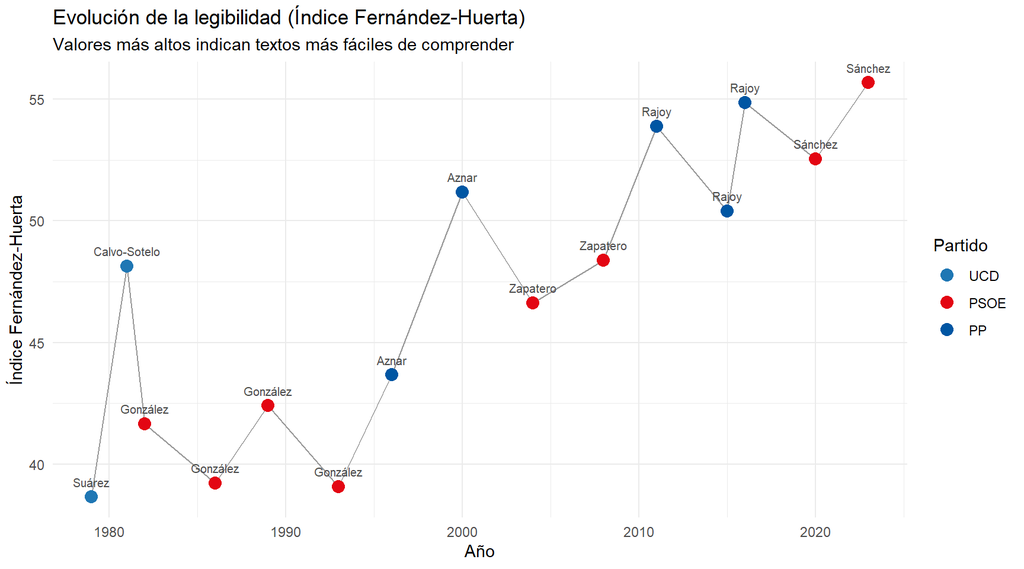

```r
contar_silabas_es <- function(palabras) {
  palabras_clean <- stringi::stri_trans_general(palabras, "Latin-ASCII")
  pmax(stringr::str_count(tolower(palabras_clean), "[aeiou]+"), 1)
}

toks_legibilidad <- tokens(discursos, remove_punct = TRUE, remove_numbers = TRUE)

n_palabras <- ntoken(toks_legibilidad)
n_frases <- nsentence(discursos)

n_silabas <- sapply(as.list(toks_legibilidad), function(p) {
  sum(contar_silabas_es(p), na.rm = TRUE)
})

legibilidad <- data.frame(
  doc_id = docnames(discursos),
  Presidente = docvars(discursos, "Presidente"),
  Partido = docvars(discursos, "Partido"),
  Año = docvars(discursos, "Año"),
  n_palabras = n_palabras,
  n_frases = n_frases,
  n_silabas = n_silabas
) %>%
  mutate(
    ASL = n_palabras / n_frases,
    silabas_por_palabra = n_silabas / n_palabras,
    Fernandez_Huerta = 206.84 - 1.02 * ASL - 60 * silabas_por_palabra
  )

ggplot(legibilidad, aes(x = Año, y = Fernandez_Huerta)) +
  geom_line(color = "grey60") +
  geom_point(aes(color = Partido), size = 3.5) +
  geom_text(aes(label = nombres_cortos[as.character(Presidente)]),
            vjust = -1.1, size = 2.7, color = "grey30", show.legend = FALSE) +
  scale_color_manual(values = colores_partidos) +
  theme_minimal() +
  labs(title = "Evolución de la legibilidad (Índice Fernández-Huerta)",
       subtitle = "Valores más altos indican textos más fáciles de comprender",
       y = "Índice Fernández-Huerta", x = "Año", color = "Partido")
```

## 2.2 Extensión del discurso

Usamos el `doc_id` en el eje X (un discurso por barra) en vez de agrupar por presidente — con varios presidentes con más de un discurso, agrupar por nombre apilaría y sumaría las frases de discursos distintos bajo la misma etiqueta, dando una cifra sin sentido.

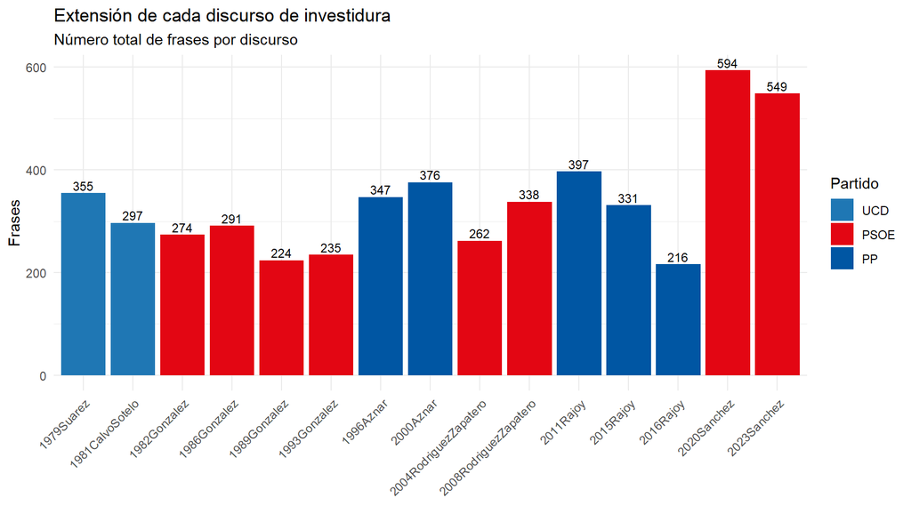

```r
resumen_corpus <- resumen_corpus %>%
  mutate(doc_id = factor(Text, levels = Text[order(docvars(discursos, "Año"))]))

ggplot(resumen_corpus, aes(x = doc_id, y = Sentences, fill = Partido)) +
  geom_bar(stat = "identity") +
  geom_text(aes(label = Sentences), vjust = -0.3, size = 3) +
  scale_fill_manual(values = colores_partidos) +
  labs(title = "Extensión de cada discurso de investidura",
       subtitle = "Número total de frases por discurso",
       x = NULL, y = "Frases", fill = "Partido") +
  theme_minimal() +
  theme(axis.text.x = element_text(angle = 45, hjust = 1))
```

## 2.3 Riqueza léxica basada en lemas (MATTR)

Al calcular el **MATTR** sobre **lemas en lugar de palabras inflectadas**, obtenemos una medida real de la diversidad temática del vocabulario, eliminando la falsa riqueza producida por las conjugaciones verbales.

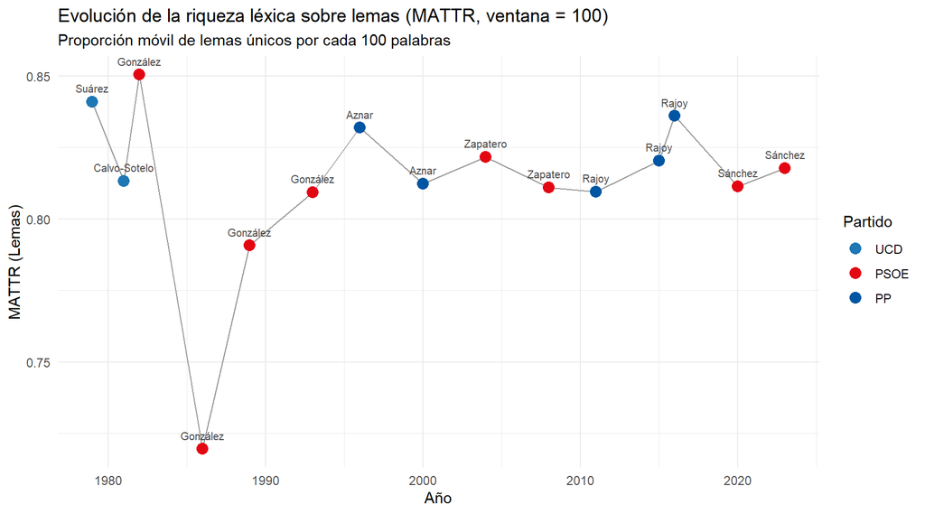

```r
riqueza_lemmas <- textstat_lexdiv(
  toks_lemmas,
  measure = "MATTR", MATTR_window = 100
)
riqueza_lemmas$Presidente <- docvars(discursos, "Presidente")
riqueza_lemmas$Partido <- docvars(discursos, "Partido")
riqueza_lemmas$Año <- docvars(discursos, "Año")

ggplot(riqueza_lemmas, aes(x = Año, y = MATTR)) +
  geom_line(color = "grey60") +
  geom_point(aes(color = Partido), size = 3.5) +
  geom_text(aes(label = nombres_cortos[as.character(Presidente)]),
            vjust = -1.1, size = 2.7, color = "grey30", show.legend = FALSE) +
  scale_color_manual(values = colores_partidos) +
  theme_minimal() +
  labs(title = "Evolución de la riqueza léxica sobre lemas (MATTR, ventana = 100)",
       subtitle = "Proporción móvil de lemas únicos por cada 100 palabras",
       y = "MATTR (Lemas)", x = "Año", color = "Partido")
```

# 3. Contenido: palabras clave y lemas

## 3.1 Lemas más frecuentes (Global)

Frecuencia absoluta de cada lema en el corpus completo, ya lematizado y sin stopwords institucionales — un primer vistazo al vocabulario dominante antes de entrar en comparaciones por presidente.

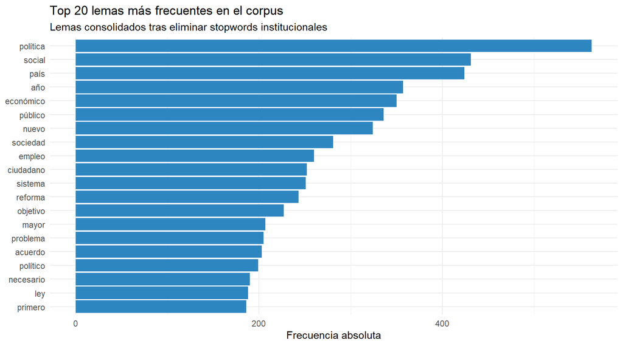

```r
top_terms_lemmas <- topfeatures(dfm_lemmas, 20)

ggplot(data.frame(lema = names(top_terms_lemmas), frecuencia = top_terms_lemmas),
       aes(x = reorder(lema, frecuencia), y = frecuencia)) +
  geom_bar(stat = "identity", fill = "#2E86C1") +
  coord_flip() +
  labs(title = "Top 20 lemas más frecuentes en el corpus",
       subtitle = "Lemas consolidados tras eliminar stopwords institucionales",
       x = NULL, y = "Frecuencia absoluta") +
  theme_minimal()
```

## 3.2 Nube de palabras comparativa por presidente

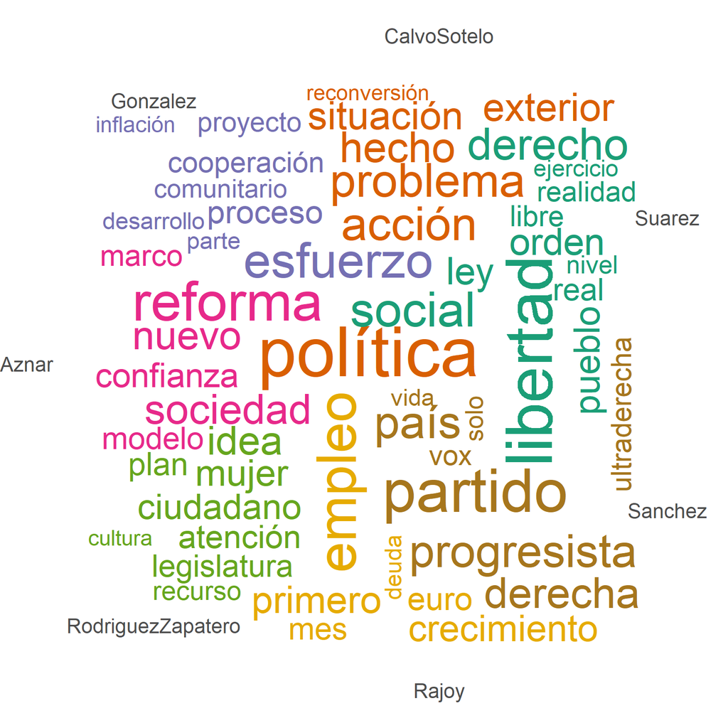

```r
dfm_por_presidente_lemmas <- dfm_lemmas %>%
  dfm_group(groups = Presidente) %>%
  dfm_trim(min_termfreq = 5)

set.seed(30)
textplot_wordcloud(dfm_por_presidente_lemmas, comparison = TRUE, max_words = 150,
                    color = RColorBrewer::brewer.pal(8, "Dark2"))
```

## 3.3 Nube de palabras con forma

Como variante visual de la comparativa anterior, generamos una nube de todo el corpus con una silueta definida en vez del típico rectángulo, usando las formas predefinidas de `wordcloud2` (sin necesidad de ninguna imagen externa).

```r
set.seed(42)  # fija el layout de la nube para que sea reproducible

frecuencias_lemas <- dfm_lemmas %>%
  dfm_trim(min_termfreq = 5) %>%
  colSums() %>%
  sort(decreasing = TRUE) %>%
  head(150)

datos_nube <- data.frame(word = names(frecuencias_lemas), freq = frecuencias_lemas)

wordcloud2(datos_nube, shape = "star", color = "random-dark", backgroundColor = "white")
```

[interactive chart not shown]

## 3.4 Perfil temático por discurso (diccionario simple)

Complementamos el *keyness* (que busca qué distingue a cada discurso frente al resto) con un diccionario temático manual: listas de palabras agrupadas por categoría, contadas directamente sobre el texto completo de cada discurso. Es una medida más burda que el *keyness* — no busca lo distintivo, solo cuenta presencia — pero responde a una pregunta distinta y complementaria: no “qué tiene de especial este discurso”, sino “cuánto de su vocabulario cae en cada categoría, en términos absolutos”.

Calculamos por **discurso individual**, no por presidente agregado — por el mismo motivo que en el *keyness*: agregar los cuatro discursos de González, por ejemplo, esconde cualquier diferencia entre 1982 y 1993.

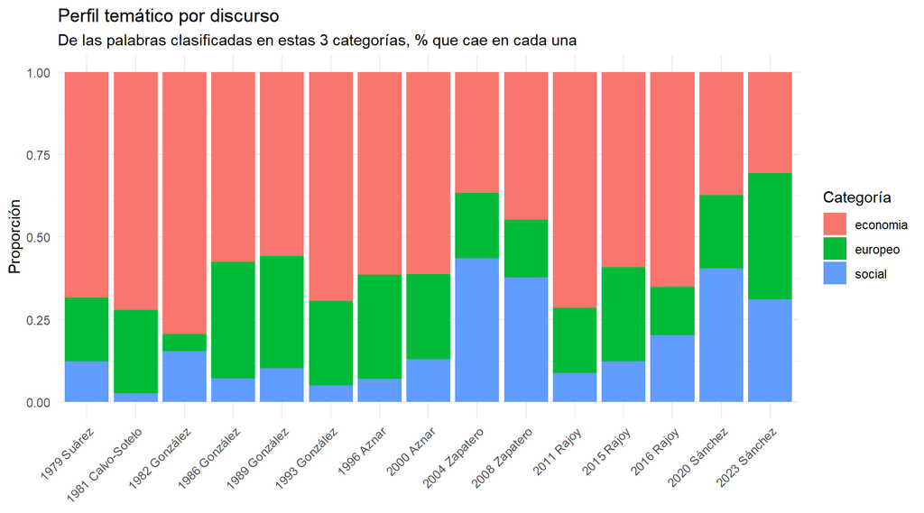

```r
diccionario_tematico <- dictionary(list(
  economia = c("empleo", "paro", "desempleo", "deuda", "presupuesto", "privatización",
               "mercado", "inflación", "impuesto", "fiscal", "económico", "crecimiento",
               "competitividad", "déficit", "recuperación"),
  social = c("mujer", "igualdad", "inmigración", "inmigrante", "sanidad", "pensión",
             "vivienda", "dependencia", "discriminación", "género", "lgtbi", "decente"),
  europeo = c("europa", "europeo", "comunitario", "comunidad", "tratado", "adhesión",
              "unión", "euro", "eurozona")
))

# Sin dfm_group(): un documento por discurso individual, no por presidente
dfm_tematico <- dfm_lemmas %>%
  dfm_lookup(diccionario_tematico)

prop_tematico <- dfm_tematico %>%
  dfm_weight(scheme = "prop") %>%
  convert(to = "data.frame") %>%
  mutate(etiqueta = factor(etiquetas_fila[doc_id], levels = orden_cronologico)) %>%
  pivot_longer(-c(doc_id, etiqueta), names_to = "categoria", values_to = "proporcion")

ggplot(prop_tematico, aes(x = etiqueta, y = proporcion, fill = categoria)) +
  geom_bar(stat = "identity", position = "fill") +
  labs(title = "Perfil temático por discurso",
       subtitle = "De las palabras clasificadas en estas 3 categorías, % que cae en cada una",
       x = NULL, y = "Proporción", fill = "Categoría") +
  theme_minimal() +
  theme(axis.text.x = element_text(angle = 45, hjust = 1))
```

### 3.4.1 Por qué NO añadimos una categoría “adversarial” a este diccionario

La primera versión de este diccionario incluía una cuarta categoría para medir lenguaje de confrontación política, descartada por dos problemas: nombrar a un rival concreto (p. ej. “vox”) solo tiene sentido a partir de 2020, y —más de fondo— un diccionario de palabras sueltas no detecta la negación. Comprobado con el texto real, el discurso con el recuento más alto (Sánchez 2020) resultó estar **rechazando** la hostilidad (“no tenemos enemigos”), no ejerciéndola — justo lo contrario de lo que sugería el número bruto. Explicación completa, con las citas y el razonamiento, en el informe (apartado 3.3.1).

Esta comprobación se puede reproducir directamente sobre el texto de origen:

```r
# Reproduce los ejemplos citados en el informe (apartado 3.3.1) directamente
# sobre el texto de los discursos, para que la afirmación sea verificable
# ejecutando el documento, no solo una cita pegada en la prosa.
extraer_contexto <- function(doc_id, patron, ventana = 80) {
  texto_plano <- gsub("[\r\n]+", " ", as.character(discursos[doc_id]))
  m <- gregexpr(patron, texto_plano, ignore.case = TRUE, perl = TRUE)[[1]]
  if (m[1] == -1) return(character(0))
  largos <- attr(m, "match.length")
  mapply(function(inicio, largo) {
    desde <- max(1, inicio - ventana)
    hasta <- min(nchar(texto_plano), inicio + largo + ventana)
    substr(texto_plano, desde, hasta)
  }, m, largos)
}

cat("--- 'enemigo' en 2020 Sánchez (rechazo, no hostilidad) ---\n")
```

```
## --- 'enemigo' en 2020 Sánchez (rechazo, no hostilidad) ---
```

```r
cat(extraer_contexto("2020Sanchez", "enemigo[s]?"), sep = "\n\n")
```

```
##  de hacer. Y así trataremos de hacerlo, señorías, desde el Gobierno. No tenemos enemigos personales en esta Cámara, créanme, no tenemos ningún enemigo personal en esta C
##
## erno. No tenemos enemigos personales en esta Cámara, créanme, no tenemos ningún enemigo personal en esta Cámara, y nos vamos a esforzar por dialogar con todos y cada un
##
## bra es el instrumento de persuasión y es, por cierto, el más poderoso. Nuestros enemigos, señorías, son la injusticia, el odio y el fanatismo. Y el único sentido de un c
##
##  de odio. Señorías he dicho que este gobierno no tratará a ninguna persona como enemigo y así será pero vamos a ser militantes contra la ideología racista contra la xen
```

```r
cat("\n--- 'división' en 2020 Sánchez (rechazo, no hostilidad) ---\n")
```

```
##
## --- 'división' en 2020 Sánchez (rechazo, no hostilidad) ---
```

```r
cat(extraer_contexto("2020Sanchez", "división"), sep = "\n\n")
```

```
## icia y de memoria que tiene que servir para empezar a cerrar definitivamente la división entre españoles; y aunque hubo personas que se sintieron molestas esa acción no
##
## alabras a que la convivencia se resienta. No traslademos desde esta tribuna más división a la calle, más discordia a las empresas, más desencuentro a las familias. Eso,
```

```r
cat("\n--- 'ataque' en 2023 Sánchez (adversarial genuino, sin negar) ---\n")
```

```
##
## --- 'ataque' en 2023 Sánchez (adversarial genuino, sin negar) ---
```

```r
cat(extraer_contexto("2023Sanchez", "ataque[s]?"), sep = "\n\n")
```

```
## orías, estamos eligiendo algo muy importante. O bien alzamos un muro ante estos ataques recurrentes a los valores de la España democrática y también constitucional, o b
##
## o de esta Cámara, democráticamente electa. Es decir, la amnistía no va a ser un ataque a la Constitución del 78, como dicen ustedes, sino todo lo contrario, será una m
```

```r
cat("\n--- 'confrontación' en 2023 Sánchez (adversarial genuino, sin negar) ---\n")
```

```
##
## --- 'confrontación' en 2023 Sánchez (adversarial genuino, sin negar) ---
```

```r
cat(extraer_contexto("2023Sanchez", "confrontación"), sep = "\n\n")
```

```
## y que digamos no a los reaccionarios cuyo único propósito es la involución y la confrontación. Vengo a proponer que prosigamos un camino que iniciamos hace un lustro, hace ci
```

Por esto, esta categoría no aparece como resultado cuantificado — el hallazgo real sobre confrontación directa (Sánchez, único presidente que nombra explícitamente a un rival político) sigue documentado, pero en el *keyness* (sección 3.5), que sí detecta distintividad léxica sin necesitar entender negaciones.

## 3.5 Keyness: lemas distintivos por discurso

`textstat_keyness()` compara un grupo “objetivo” frente al resto del corpus combinado, y extrae mediante una prueba chi-cuadrado qué lemas están estadísticamente más asociados a ese grupo. Calculamos **cada discurso individual contra el resto** (no cada presidente agregado) — así podemos ver si hay variación dentro de un mismo presidente entre distintas legislaturas (por ejemplo, Aznar 1996, con necesidad de apoyos de PNV/CiU, frente a Aznar 2000, con mayoría absoluta), algo que se pierde si se agregan sus dos discursos en un solo bloque. También mantiene la coherencia con el resto del documento, que ya trabaja discurso a discurso en casi todas las secciones.

Con 15 discursos y 8 palabras por panel, un único gráfico queda demasiado apretado para leerse con comodidad. En vez de recortar palabras, lo partimos en dos por época — cada mitad respira mucho más sin perder ninguna de las 8.

```r
dfm_keyness <- dfm_lemmas %>%
  dfm_trim(min_termfreq = 3)

keyness_lemmas <- lapply(docnames(dfm_keyness), function(doc) {
  resultado <- textstat_keyness(dfm_keyness, target = doc)
  resultado$doc_id <- doc
  resultado %>%
    filter(chi2 > 0) %>%
    slice_max(chi2, n = 8)
}) %>%
  bind_rows() %>%
  mutate(
    etiqueta = factor(etiquetas_fila[doc_id], levels = orden_cronologico),
    Partido  = docvars(discursos, "Partido")[match(doc_id, docnames(discursos))],
    Año      = docvars(discursos, "Año")[match(doc_id, docnames(discursos))]
  )

plot_keyness <- function(datos, titulo) {
  ggplot(datos,
         aes(x = reorder_within(feature, chi2, etiqueta), y = chi2, fill = Partido)) +
    geom_col(show.legend = TRUE) +
    scale_x_reordered() +
    scale_fill_manual(values = colores_partidos) +
    coord_flip() +
    facet_wrap(~ etiqueta, scales = "free", ncol = 2) +
    labs(title = titulo,
         subtitle = "Fuerza de asociación medida con prueba Chi-cuadrado -- por discurso, no por presidente",
         x = NULL, y = "Chi-cuadrado (Asociación)") +
    theme_minimal(base_size = 12)
}
```

**Transición y consolidación democrática (1979-2000):**

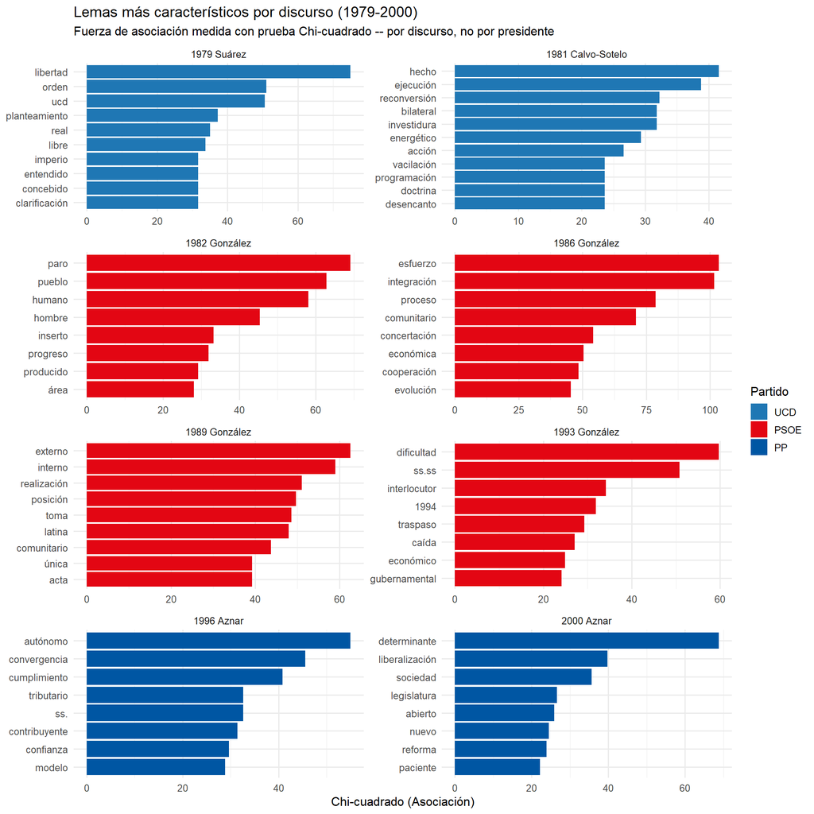

```r
plot_keyness(keyness_lemmas %>% filter(Año < 2004),
             "Lemas más característicos por discurso (1979-2000)")
```

**Etapa reciente (2004-2023):**

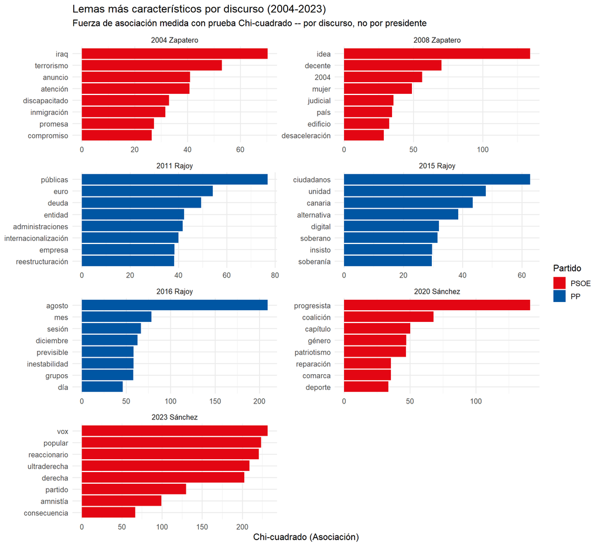

```r
plot_keyness(keyness_lemmas %>% filter(Año >= 2004),
             "Lemas más característicos por discurso (2004-2023)")
```

## 3.6 Contexto de palabras clave (KWIC)

```r
toks_sin_limpiar <- tokens(discursos, remove_punct = TRUE)

# etiquetas_fila / orden_fila ya están calculadas en la sección 1 (se
# reutilizan aquí y en el resto de gráficos del documento)
plot_kwic_tematico <- function(terminos, titulo) {
  resultado_kwic <- kwic(toks_sin_limpiar, pattern = terminos)
  if (nrow(resultado_kwic) > 0) {
    resultado_kwic$docname <- factor(etiquetas_fila[as.character(resultado_kwic$docname)],
                                       levels = orden_fila)
  }
  textplot_xray(resultado_kwic) +
    aes(color = keyword) +
    labs(title = titulo, y = "Discurso (año y presidente)") +
    theme_bw(base_size = 11) +
    theme(
      panel.grid.minor = element_blank(),
      axis.text.y = element_blank(),
      axis.ticks.y = element_blank(),
      strip.background = element_rect(fill = "grey95"),
      strip.text.y = element_text(angle = 0, size = 7)
    )
}
```

Cada gráfico se limita a 2-3 términos de un mismo eje temático — meter más satura la lectura. Estos son los seis ejes elegidos, cada uno pensado para trazar un arco histórico reconocible en 44 años de discursos:

**Terrorismo y paz** — presencia casi constante hasta la disolución de ETA (2018):

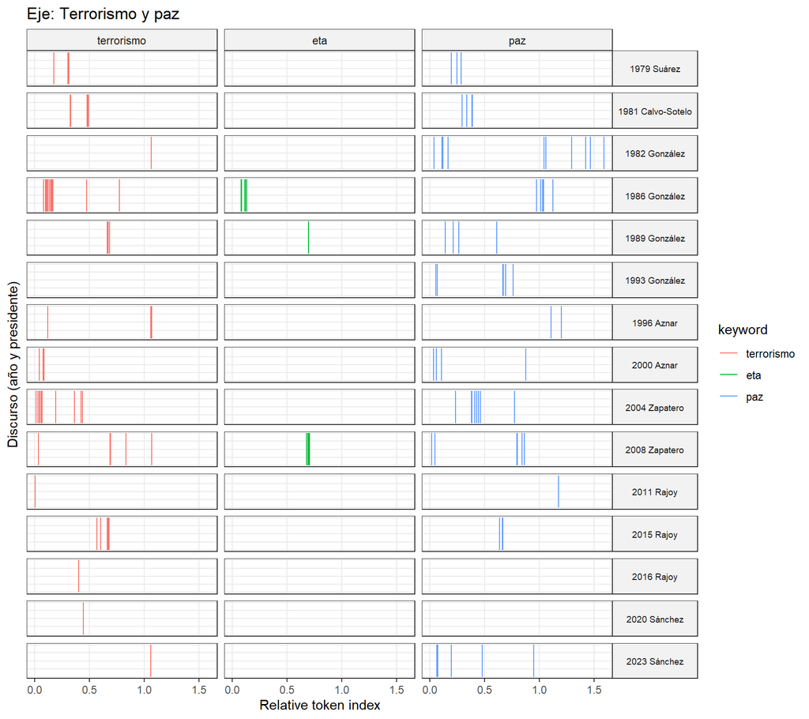

```r
plot_kwic_tematico(c("terrorismo", "eta", "paz"), "Eje: Terrorismo y paz")
```

**Integración europea** — desde la entrada en la CEE (1986) hasta el euro:

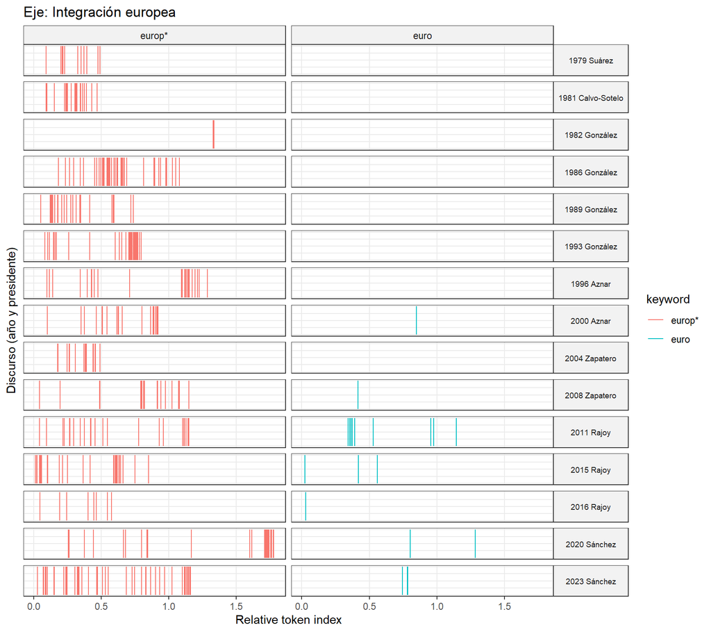

```r
plot_kwic_tematico(c("europ*", "euro"), "Eje: Integración europea")
```

**Economía y crisis** — las dos grandes crisis económicas (1993 y 2008-2011):

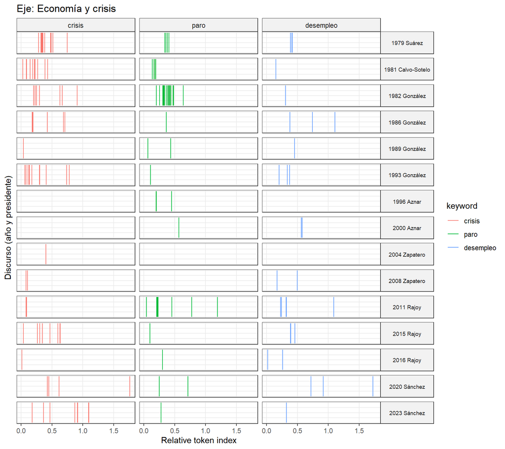

```r
plot_kwic_tematico(c("crisis", "paro", "desempleo"), "Eje: Economía y crisis")
```

**Cuestión territorial** — especialmente relevante desde 2010 en adelante:

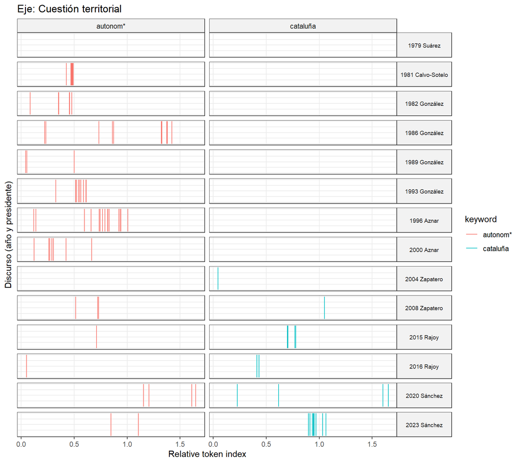

```r
plot_kwic_tematico(c("autonom*", "cataluña"), "Eje: Cuestión territorial")
```

**Igualdad** — hipótesis: mayor presencia cuanto más reciente el discurso:

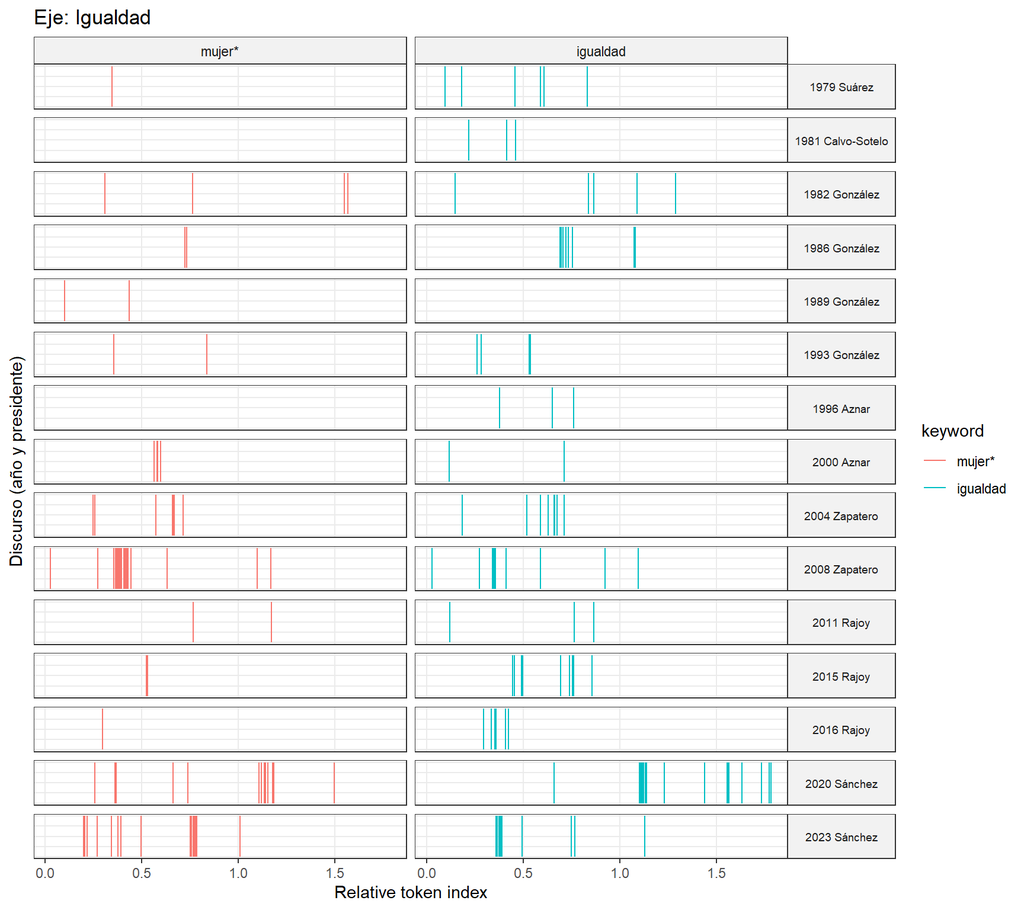

```r
plot_kwic_tematico(c("mujer*", "igualdad"), "Eje: Igualdad")
```

**Gobernabilidad y pactos** — especialmente relevante en gobiernos de coalición o en minoría (Sánchez 2020/2023) frente a las mayorías absolutas de otras épocas:

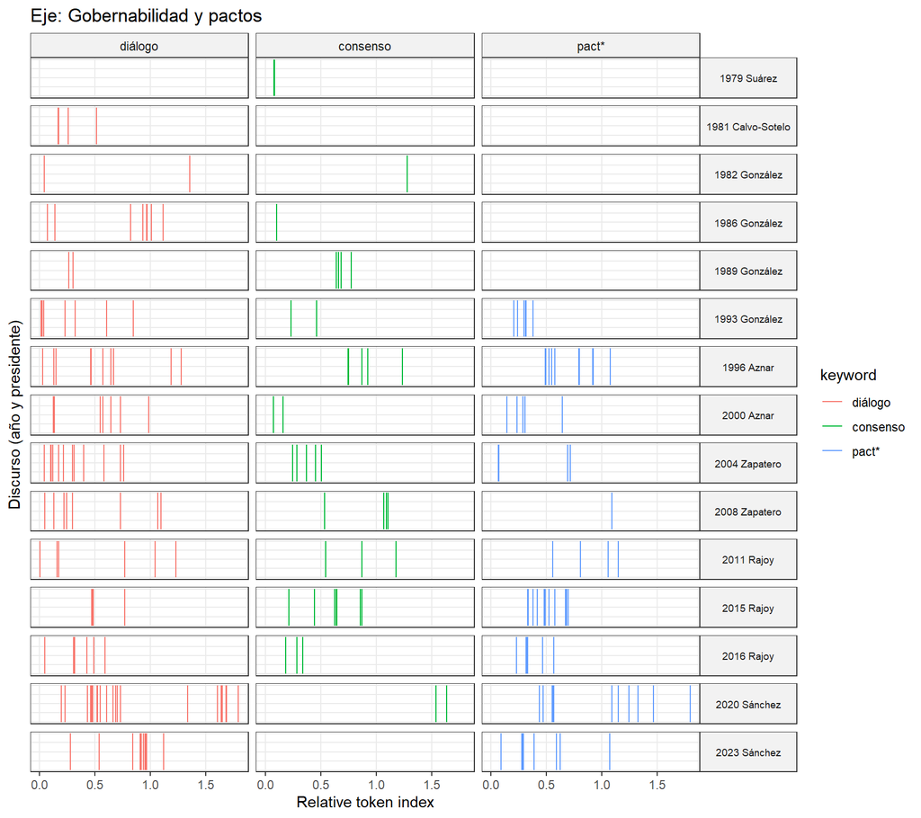

```r
plot_kwic_tematico(c("diálogo", "consenso", "pact*"), "Eje: Gobernabilidad y pactos")
```

# 4. Similitud entre discursos (Ponderación TF-IDF)

## 4.1 Matriz de similitud coseno con TF-IDF

Al transformar la matriz DFM a valores **TF-IDF** (*Term Frequency - Inverse Document Frequency*), penalizamos las palabras que aparecen por igual en todos los discursos y premiamos la coincidencia en términos específicos. Esto soluciona la excesiva homogeneidad de la versión no ponderada.

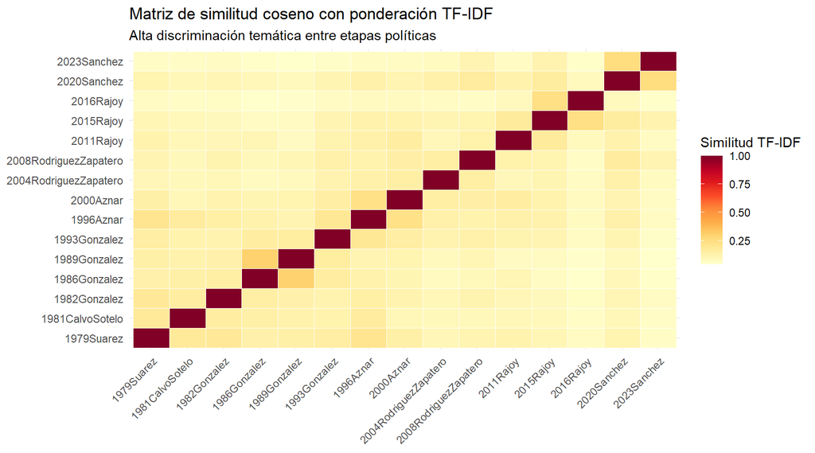

```r
dfm_tfidf_lemmas <- dfm_tfidf(dfm_lemmas)

similitud_tfidf <- textstat_simil(dfm_tfidf_lemmas, method = "cosine", margin = "documents")
similitud_matrix_tfidf <- as.matrix(similitud_tfidf)

df_similitud_tfidf <- as.data.frame(similitud_matrix_tfidf) %>%
  mutate(doc1 = factor(rownames(.), levels = docnames(discursos))) %>%
  pivot_longer(-doc1, names_to = "doc2", values_to = "similitud") %>%
  mutate(doc2 = factor(doc2, levels = docnames(discursos)))

ggplot(df_similitud_tfidf, aes(x = doc1, y = doc2, fill = similitud)) +
  geom_tile(color = "white") +
  scale_fill_gradientn(colours = RColorBrewer::brewer.pal(9, "YlOrRd"), name = "Similitud TF-IDF") +
  labs(title = "Matriz de similitud coseno con ponderación TF-IDF",
       subtitle = "Alta discriminación temática entre etapas políticas",
       x = NULL, y = NULL) +
  theme_minimal(base_size = 11) +
  theme(axis.text.x = element_text(angle = 45, hjust = 1))
```

## 4.2 Clustering jerárquico ponderado

Agrupa los discursos según lo parecidos que son en su vocabulario, partiendo de la **misma matriz de similitud TF-IDF** del apartado anterior (convertida a distancia como `1 - similitud`) para que heatmap y dendrograma cuenten la misma historia con la misma métrica. Usamos `ward.D2` como método de enlace porque minimiza la varianza dentro de cada grupo y evita el “efecto cadena” (clusters alargados y poco informativos) típico de otros métodos como `average`. Lo interesante de leer aquí no es tanto qué dos discursos concretos se juntan primero, sino **a qué altura se separan los grandes bloques** — cuanto más alto el punto de unión, más distintos son entre sí.

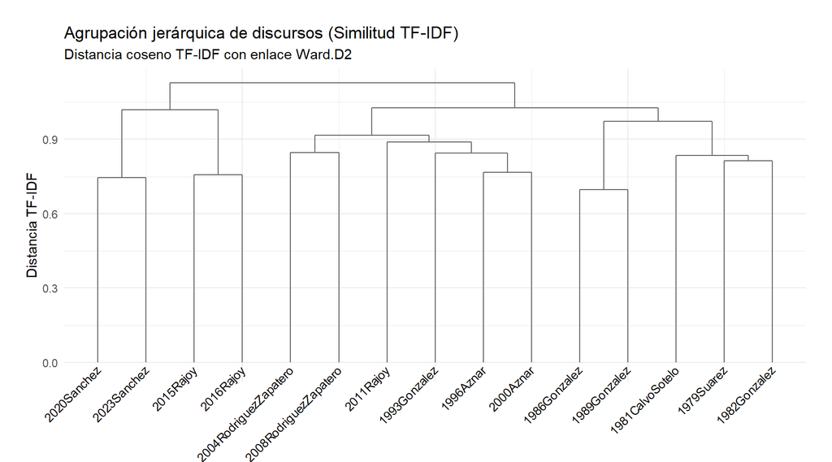

```r
distancias_tfidf <- as.dist(1 - similitud_matrix_tfidf)
hc_tfidf <- hclust(distancias_tfidf, method = "ward.D2")

dendro_tfidf <- dendro_data(hc_tfidf, type = "rectangle")
dendro_tfidf$labels$label <- str_wrap(dendro_tfidf$labels$label, width = 20)

ggplot() +
  geom_segment(data = dendro_tfidf$segments,
               aes(x = x, y = y, xend = xend, yend = yend), color = "grey40") +
  geom_text(data = dendro_tfidf$labels,
            aes(x = x, y = y - 0.02, label = label),
            angle = 45, hjust = 1, size = 3.3) +
  labs(title = "Agrupación jerárquica de discursos (Similitud TF-IDF)",
       subtitle = "Distancia coseno TF-IDF con enlace Ward.D2",
       x = NULL, y = "Distancia TF-IDF") +
  coord_cartesian(clip = "off") +
  theme_minimal() +
  theme(axis.text.x = element_blank(), axis.ticks.x = element_blank(),
        plot.margin = margin(t = 20, r = 20, b = 60, l = 20))
```

# 5. Modelado de temas (*Structural Topic Model - STM*)

A través de **STM** podemos agrupar las palabras en $K=5$ tópicos latentes o agendas de gobierno, estimando la proporción de cada tópico según el partido político y la evolución temporal.

**Aviso metodológico importante, léelo antes de interpretar los resultados:** STM está pensado habitualmente para corpus de cientos o miles de documentos. Aquí tenemos **15**. La fórmula de prevalencia `~ Partido + ns(Año, df = 3)` implica estimar del orden de 5-6 parámetros — casi tantos como documentos hay en el corpus. Esto significa que el modelo tiene un margen enorme para sobreajustar: los 5 temas que salgan pueden depender bastante de qué 15 discursos concretos tengamos, y probablemente cambiarían si quitas un discurso o cambias la semilla aleatoria. Trata esta sección como una **exploración ilustrativa de la técnica**, no como una conclusión firme sobre las agendas políticas reales — y dilo así explícitamente si presentas este proyecto, en vez de afirmar los temas como un hallazgo consolidado.

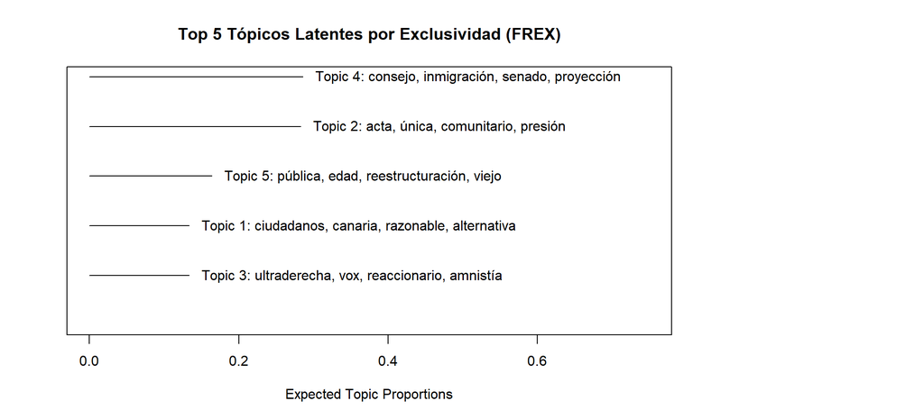

```r
library(splines)

# 1. Filtro de stopwords políticas y conectores
#    (incluye "señorías" además de "señoría" por el mismo motivo explicado
#    en la sección 1.2: UDPipe no lematiza esta palabra al 100% de precisión)
stopwords_politica <- c(
  "señoría", "señorías", "política", "político", "país", "español", "social",
  "nacional", "problema", "nuevo", "necesario", "general", "medida",
  "pues", "consiguiente", "vista", "agosto", "junio"
)

dfm_stm_limpia <- dfm_lemmas %>%
  dfm_remove(stopwords_politica) %>%
  dfm_trim(max_docfreq = 0.75, docfreq_type = "prop", min_termfreq = 3)

# 2. Convertir a formato STM
stm_data <- convert(dfm_stm_limpia, to = "stm")
stm_data$meta$Año <- as.numeric(stm_data$meta$Año)

set.seed(123)
modelo_stm <- stm(
  documents  = stm_data$documents,
  vocab      = stm_data$vocab,
  K          = 5,
  prevalence = ~ Partido + ns(Año, df = 3),
  data       = stm_data$meta,
  verbose    = FALSE
)

# 3. Gráfico con margen derecho extra amplio (15) y límite X ampliado (0.75)
op <- par(mar = c(5, 4, 4, 15))
plot(
  modelo_stm,
  type = "summary",
  labeltype = "frex",
  n = 4,
  main = "Top 5 Tópicos Latentes por Exclusividad (FREX)",
  xlim = c(0, 0.75)
)
```

```r
par(op) # Restaurar márgenes por defecto
```

```r
labelTopics(modelo_stm, n = 10)
```

```
## Topic 1 Top Words:
##       Highest Prob: popular, pacto, ciudadanos, coalición, euro, recuperación, voto, soberanía, urgencia, sesión
##       FREX: ciudadanos, canaria, razonable, alternativa, soberano, soberanía, fiable, sesión, grupos, diciembre
##       Lift: espalda, eurozona, solitario, tranquilizador, yihadista, ciudadanos, previsible, inestabilidad, aragonés, navarro
##       Score: espalda, ciudadanos, alternativa, yihadista, diciembre, previsible, canaria, eurozona, solitario, tranquilizador
## Topic 2 Top Words:
##       Highest Prob: comunitario, interno, progreso, recuperación, tema, juicio, construcción, respecto, industrial, económica
##       FREX: acta, única, comunitario, presión, juicio, interno, respecto, tema, alianza, 1992
##       Lift: cláusula, convencional, debido, defraudación, discrepancia, este-oeste, explicación, llamamiento, maquinaria, polémica
##       Score: cláusula, acta, única, realización, comunitario, cuadro, tratado, interno, alianza, adhesión
## Topic 3 Top Words:
##       Highest Prob: popular, progresista, derecha, coalición, ejemplo, solo, ultraderecha, vox, reaccionario, autónomo
##       FREX: ultraderecha, vox, reaccionario, amnistía, derecha, progresista, lgtbi, odio, sexual, género
##       Lift: abascal, aberración, adolescencia, amnistía, argentina, argentino, aspaviento, azar, bancada, biodiversidad
##       Score: vox, reaccionario, ultraderecha, derecha, abascal, amnistía, odio, lgtbi, muchísimo, ucrania
## Topic 4 Top Words:
##       Highest Prob: consejo, idea, pleno, pacto, innovación, información, autónomo, familia, convivencia, cohesión
##       FREX: consejo, inmigración, senado, proyección, información, idea, telecomunicación, convergencia, corresponsabilidad, autonomías
##       Lift: 2004, anuncio, cervantes, concertado, edificio, físicas, iberoamericana, infraestructuras, iraq, pauta
##       Score: iraq, inmigración, decente, autonomías, inmigrante, idea, consejo, 2004, telecomunicación, conocimiento
## Topic 5 Top Words:
##       Highest Prob: orden, preciso, euro, siguiente, criterio, libre, independencia, familia, jurídico, administrativo
##       FREX: pública, edad, reestructuración, viejo, independencia, ucd, públicas, criterio, entidad, estatal
##       Lift: cee, coordenada, indirecto, oculto, precepto, venta, bancario, centralización, condicionamiento, pluralista
##       Score: venta, ucd, orden, centralización, condicionamiento, pluralista, realización, pública, clarificación, imperio
```

## 5.2 Evolución de tópicos por partido y época

`theta` es la matriz que guarda, para cada discurso, **qué proporción de su contenido corresponde a cada uno de los 5 tópicos** (las filas suman 1). El gráfico de barras apiladas muestra esa proporción año a año; la tabla de abajo la deja en formato consultable, fila por discurso.

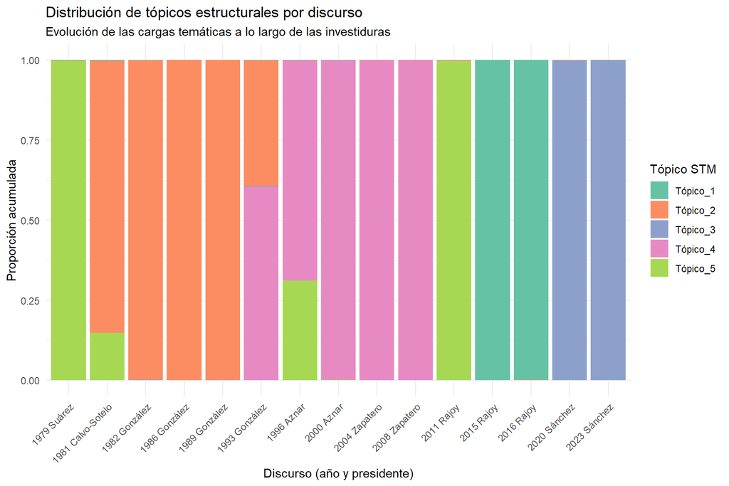

```r
# Extraer la matriz de proporciones de tópicos por documento (Theta)
theta_df <- as.data.frame(modelo_stm$theta)
colnames(theta_df) <- paste0("Tópico_", 1:5)

# Vinculación segura de metadatos desde la estructura stm_data$meta
theta_df$Presidente <- stm_data$meta$Presidente
theta_df$Partido    <- stm_data$meta$Partido
theta_df$Año        <- stm_data$meta$Año
theta_df$etiqueta   <- paste(theta_df$Año, nombres_cortos[as.character(theta_df$Presidente)])

# Reestructuración a formato largo para ggplot
theta_long <- theta_df %>%
  pivot_longer(cols = starts_with("Tópico_"), names_to = "Topico", values_to = "Proporcion") %>%
  mutate(etiqueta = factor(etiqueta, levels = orden_cronologico))

# Gráfico de barras apiladas por año
ggplot(theta_long, aes(x = etiqueta, y = Proporcion, fill = Topico)) +
  geom_bar(stat = "identity", position = "stack") +
  scale_fill_brewer(palette = "Set2", name = "Tópico STM") +
  labs(title = "Distribución de tópicos estructurales por discurso",
       subtitle = "Evolución de las cargas temáticas a lo largo de las investiduras",
       x = "Discurso (año y presidente)", y = "Proporción acumulada") +
  theme_minimal() +
  theme(axis.text.x = element_text(angle = 45, hjust = 1))
```

```r
# Tabla de proporciones tema-documento, para consulta directa (no solo el gráfico apilado)
theta_export <- theta_df %>%
  mutate(across(starts_with("Tópico_"), ~ round(.x, 3))) %>%
  select(Año, Presidente, Partido, everything())

datatable(theta_export, rownames = FALSE,
          caption = "Proporción de cada tópico STM (K=5) por discurso")
```

| Año | Presidente | Partido | Tópico_1 | Tópico_2 | Tópico_3 | Tópico_4 | Tópico_5 | etiqueta |
| --- | --- | --- | --- | --- | --- | --- | --- | --- |
| 1979 | Suarez | UCD | 0.001 | 0.001 | 0 | 0 | 0.997 | 1979 Suárez |
| 1981 | CalvoSotelo | UCD | 0.002 | 0.85 | 0 | 0 | 0.148 | 1981 Calvo-Sotelo |
| 1982 | Gonzalez | PSOE | 0 | 0.999 | 0 | 0 | 0.001 | 1982 González |
| 1986 | Gonzalez | PSOE | 0 | 0.999 | 0 | 0 | 0 | 1986 González |
| 1989 | Gonzalez | PSOE | 0 | 0.999 | 0 | 0.001 | 0 | 1989 González |
| 1993 | Gonzalez | PSOE | 0 | 0.394 | 0.002 | 0.604 | 0 | 1993 González |
| 1996 | Aznar | PP | 0.001 | 0.002 | 0 | 0.686 | 0.311 | 1996 Aznar |
| 2000 | Aznar | PP | 0.001 | 0 | 0 | 0.997 | 0.002 | 2000 Aznar |
| 2004 | RodriguezZapatero | PSOE | 0 | 0.001 | 0 | 0.999 | 0 | 2004 Zapatero |
| 2008 | RodriguezZapatero | PSOE | 0 | 0.001 | 0.001 | 0.998 | 0 | 2008 Zapatero |

[output cut: 5 more lines]

## 5.3 STM alternativo (K=3, sin covariables de prevalencia)

*Prueba de robustez frente al modelo principal (K=5, con covariables). Si los temas que salen aquí son razonablemente parecidos a una versión “fusionada” de los 5 anteriores, es una señal (no una prueba definitiva) de que el modelo está capturando algo mínimamente estable y no puro ruido de sobreajuste. Si salen completamente distintos, es la señal contraria.*

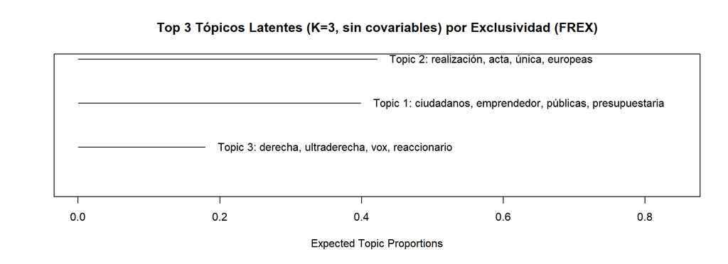

```r
set.seed(123)
modelo_stm_k3 <- stm(
  documents  = stm_data$documents,
  vocab      = stm_data$vocab,
  K          = 3,
  data       = stm_data$meta,
  verbose    = FALSE
)

plot(modelo_stm_k3, type = "summary", labeltype = "frex", n = 4,
     main = "Top 3 Tópicos Latentes (K=3, sin covariables) por Exclusividad (FREX)")
```

```r
labelTopics(modelo_stm_k3, n = 10)
```

```
## Topic 1 Top Words:
##       Highest Prob: pacto, euro, consejo, popular, pleno, innovación, autónomo, convivencia, públicas, familia
##       FREX: ciudadanos, emprendedor, públicas, presupuestaria, canaria, telecomunicación, basado, beneficio, consejo, requisito
##       Lift: angular, cabeza, cápita, ciudadanos, cobro, cotizante, credibilidad, doméstico, espalda, estilo
##       Score: espalda, ciudadanos, euro, presupuestos, ritmo, canaria, trimestre, liberalización, austeridad, consumidor
## Topic 2 Top Words:
##       Highest Prob: orden, progreso, construcción, interno, previsto, hombre, comunitario, industrial, aspecto, equilibrio
##       FREX: realización, acta, única, europeas, interno, 1992, aspecto, previsto, económica, occidental
##       Lift: aislamiento, relacionado, 1989, 1992, acercamiento, agresivo, amplitud, árabe, arma, autenticidad
##       Score: realización, cláusula, acta, única, aspecto, económica, europeas, tratado, adhesión, alianza
## Topic 3 Top Words:
##       Highest Prob: popular, progresista, derecha, idea, solo, coalición, ejemplo, climático, ultraderecha, vox
##       FREX: derecha, ultraderecha, vox, reaccionario, amnistía, progresista, emergencia, patriotismo, género, climático
##       Lift: adolescencia, azar, biodiversidad, capricho, co2, comarca, comedor, cordón, curioso, diputada
##       Score: derecha, vox, ultraderecha, reaccionario, abascal, amnistía, odio, lgtbi, muchísimo, ucrania
```

## 5.4 Proporción de tópicos por discurso (STM K=3, sin covariables)

Mismo concepto de `theta` que en 5.2, aplicado ahora al modelo K=3 sin covariables — compara este reparto con el de arriba para juzgar si ambos modelos cuentan una historia parecida o no.

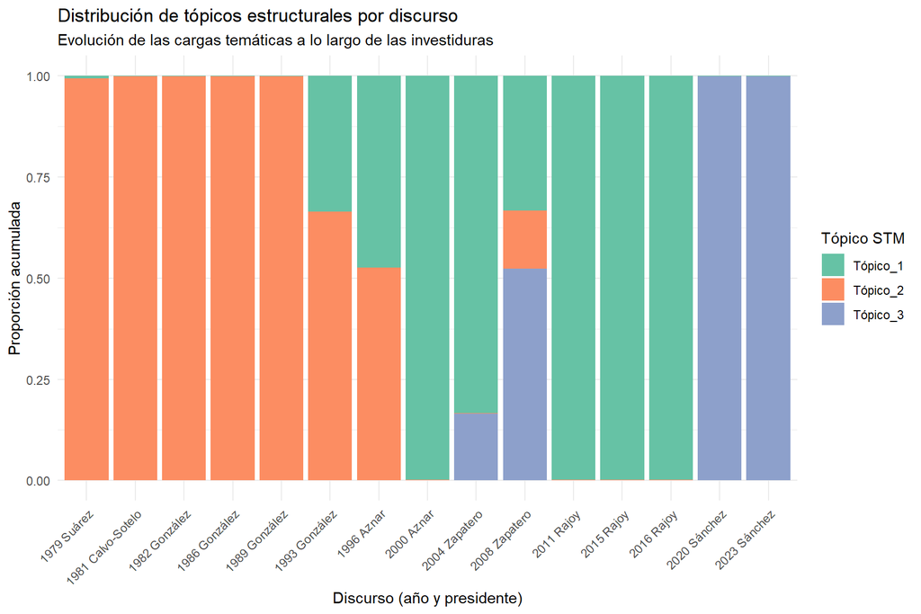

```r
# Extraer la matriz de proporciones de tópicos por documento (Theta)
theta_df_k3 <- as.data.frame(modelo_stm_k3$theta)
colnames(theta_df_k3) <- paste0("Tópico_", 1:3)

# Vinculación segura de metadatos desde la estructura stm_data$meta
theta_df_k3$Presidente <- stm_data$meta$Presidente
theta_df_k3$Partido    <- stm_data$meta$Partido
theta_df_k3$Año        <- stm_data$meta$Año
theta_df_k3$etiqueta   <- paste(theta_df_k3$Año, nombres_cortos[as.character(theta_df_k3$Presidente)])

# Reestructuración a formato largo para ggplot
theta_long_k3 <- theta_df_k3 %>%
  pivot_longer(cols = starts_with("Tópico_"), names_to = "Topico", values_to = "Proporcion") %>%
  mutate(etiqueta = factor(etiqueta, levels = orden_cronologico))

# Gráfico de barras apiladas por año
ggplot(theta_long_k3, aes(x = etiqueta, y = Proporcion, fill = Topico)) +
  geom_bar(stat = "identity", position = "stack") +
  scale_fill_brewer(palette = "Set2", name = "Tópico STM") +
  labs(title = "Distribución de tópicos estructurales por discurso",
       subtitle = "Evolución de las cargas temáticas a lo largo de las investiduras",
       x = "Discurso (año y presidente)", y = "Proporción acumulada") +
  theme_minimal() +
  theme(axis.text.x = element_text(angle = 45, hjust = 1))
```

```r
# Tabla de proporciones tema-documento, para consulta directa (no solo el gráfico apilado)
theta_export_k3 <- theta_df_k3 %>%
  mutate(across(starts_with("Tópico_"), ~ round(.x, 3))) %>%
  select(Año, Presidente, Partido, everything())

datatable(theta_export_k3, rownames = FALSE,
          caption = "Proporción de cada tópico STM (K=3) por discurso")
```

| Año | Presidente | Partido | Tópico_1 | Tópico_2 | Tópico_3 | etiqueta |
| --- | --- | --- | --- | --- | --- | --- |
| 1979 | Suarez | UCD | 0.006 | 0.994 | 0 | 1979 Suárez |
| 1981 | CalvoSotelo | UCD | 0.001 | 0.999 | 0 | 1981 Calvo-Sotelo |
| 1982 | Gonzalez | PSOE | 0.001 | 0.999 | 0 | 1982 González |
| 1986 | Gonzalez | PSOE | 0 | 0.999 | 0 | 1986 González |
| 1989 | Gonzalez | PSOE | 0.001 | 0.999 | 0 | 1989 González |
| 1993 | Gonzalez | PSOE | 0.335 | 0.664 | 0.001 | 1993 González |
| 1996 | Aznar | PP | 0.474 | 0.526 | 0.001 | 1996 Aznar |
| 2000 | Aznar | PP | 0.999 | 0.001 | 0 | 2000 Aznar |
| 2004 | RodriguezZapatero | PSOE | 0.834 | 0.001 | 0.165 | 2004 Zapatero |
| 2008 | RodriguezZapatero | PSOE | 0.333 | 0.144 | 0.523 | 2008 Zapatero |

[output cut: 5 more lines]

# 6. Sentimiento y perfil emocional

## 6.1 Tono neto de sentimiento

Usamos `syuzhet::get_nrc_sentiment(language = "spanish")`, que aplica una traducción del léxico NRC al español para clasificar cada palabra como positiva o negativa.

**Aviso honesto**: ese léxico en español es una **traducción automática** del original en inglés, no un diccionario validado nativamente para español — de ahí que en la sección 6.3 lo complementemos con ML-Senticon, un léxico revisado por hablantes nativos. Trata esta sección como una aproximación exploratoria del tono, no como una medición de referencia.

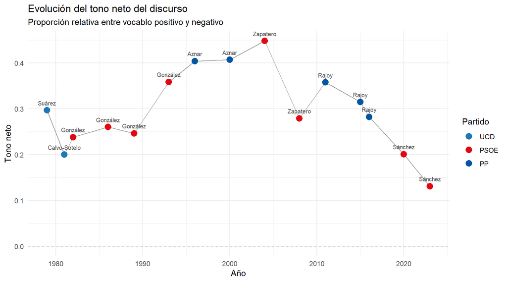

```r
textos_raw <- as.character(discursos)
sentimientos <- get_nrc_sentiment(textos_raw, language = "spanish")

df_sent <- data.frame(
  doc_id     = docnames(discursos),
  Presidente = docvars(discursos, "Presidente"),
  Partido    = docvars(discursos, "Partido"),
  Año        = docvars(discursos, "Año"),
  positive   = sentimientos$positive,
  negative   = sentimientos$negative
) %>%
  mutate(tono_neto = (positive - negative) / (positive + negative))

ggplot(df_sent, aes(x = Año, y = tono_neto)) +
  geom_hline(yintercept = 0, linetype = "dashed", color = "grey60") +
  geom_line(color = "grey60") +
  geom_point(aes(color = Partido), size = 3.5) +
  geom_text(aes(label = nombres_cortos[as.character(Presidente)]),
            vjust = -1.1, size = 2.7, color = "grey30", show.legend = FALSE) +
  scale_color_manual(values = colores_partidos) +
  labs(title = "Evolución del tono neto del discurso",
       subtitle = "Proporción relativa entre vocablo positivo y negativo",
       y = "Tono neto", x = "Año", color = "Partido") +
  theme_minimal()
```

## 6.2 Desglose de emociones discretas (NRC)

Más allá del tono positivo/negativo, el léxico NRC clasifica palabras en ocho emociones básicas del modelo de Plutchik (ira, anticipación, asco, miedo, alegría, tristeza, sorpresa, confianza). El mismo aviso de la sección 6.1 sobre la traducción automática aplica aquí también — y con más motivo, porque clasificar en 8 categorías finas es más exigente para un léxico traducido que una simple polaridad positivo/negativo.

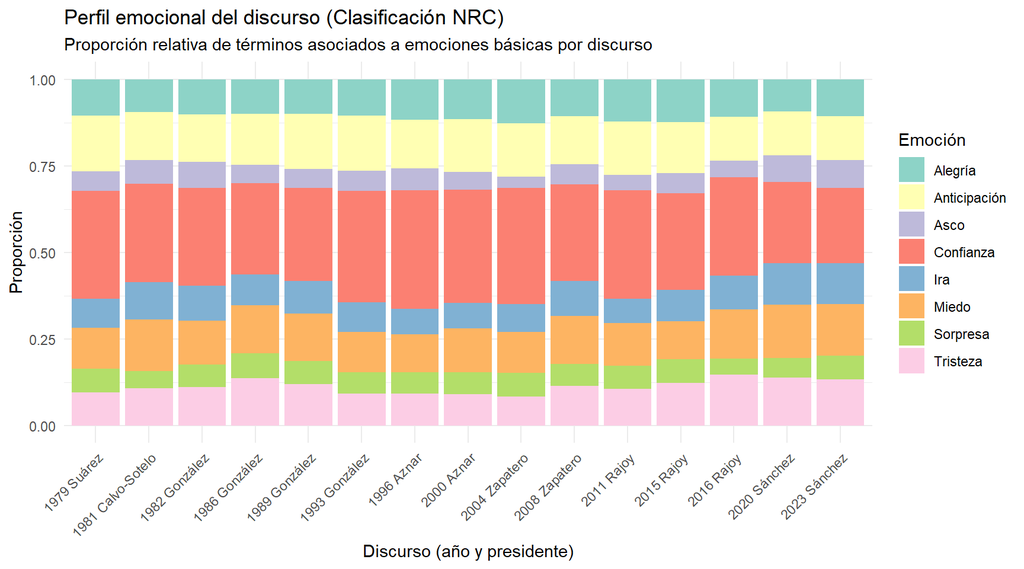

```r
emociones_df <- sentimientos %>%
  select(-positive, -negative) %>%
  mutate(
    doc_id     = docnames(discursos),
    Presidente = docvars(discursos, "Presidente"),
    Partido    = docvars(discursos, "Partido"),
    Año        = docvars(discursos, "Año"),
    etiqueta   = factor(paste(Año, nombres_cortos[as.character(Presidente)]), levels = orden_cronologico)
  ) %>%
  pivot_longer(
    cols = c(anger, anticipation, disgust, fear, joy, sadness, surprise, trust),
    names_to = "emocion", values_to = "conteo"
  ) %>%
  group_by(doc_id) %>%
  mutate(prop = conteo / sum(conteo)) %>%
  ungroup()

emociones_es <- c(
  "anger" = "Ira", "anticipation" = "Anticipación", "disgust" = "Asco",
  "fear" = "Miedo", "joy" = "Alegría", "sadness" = "Tristeza",
  "surprise" = "Sorpresa", "trust" = "Confianza"
)
emociones_df$emocion_es <- emociones_es[emociones_df$emocion]

ggplot(emociones_df, aes(x = etiqueta, y = prop, fill = emocion_es)) +
  geom_bar(stat = "identity", position = "fill") +
  scale_fill_brewer(palette = "Set3", name = "Emoción") +
  labs(title = "Perfil emocional del discurso (Clasificación NRC)",
       subtitle = "Proporción relativa de términos asociados a emociones básicas por discurso",
       x = "Discurso (año y presidente)", y = "Proporción") +
  theme_minimal() +
  theme(axis.text.x = element_text(angle = 45, hjust = 1))
```

Un gráfico de barras apiladas es cómodo para ver la tendencia general, pero comparar la altura exacta de un segmento intermedio (por ejemplo, “Ira” entre dos discursos) a simple vista es poco fiable — el ojo no mide bien alturas que no arrancan desde cero. Para eso, aquí está la misma información en formato numérico, un discurso por fila:

```r
emociones_tabla <- emociones_df %>%
  select(etiqueta, emocion_es, prop) %>%
  mutate(prop = round(prop, 3)) %>%
  pivot_wider(names_from = emocion_es, values_from = prop)

datatable(emociones_tabla, rownames = FALSE,
          caption = "Proporción exacta de cada emoción NRC por discurso",
          options = list(pageLength = 15))
```

| etiqueta | Ira | Anticipación | Asco | Miedo | Alegría | Tristeza | Sorpresa | Confianza |
| --- | --- | --- | --- | --- | --- | --- | --- | --- |
| 1979 Suárez | 0.082 | 0.159 | 0.057 | 0.118 | 0.106 | 0.095 | 0.07 | 0.312 |
| 1981 Calvo-Sotelo | 0.108 | 0.138 | 0.069 | 0.148 | 0.095 | 0.108 | 0.049 | 0.284 |
| 1982 González | 0.102 | 0.136 | 0.076 | 0.127 | 0.102 | 0.112 | 0.064 | 0.282 |
| 1986 González | 0.089 | 0.148 | 0.052 | 0.139 | 0.1 | 0.137 | 0.072 | 0.263 |
| 1989 González | 0.093 | 0.158 | 0.055 | 0.138 | 0.101 | 0.121 | 0.065 | 0.269 |
| 1993 González | 0.086 | 0.159 | 0.058 | 0.116 | 0.106 | 0.093 | 0.06 | 0.322 |
| 1996 Aznar | 0.074 | 0.141 | 0.063 | 0.11 | 0.117 | 0.092 | 0.061 | 0.342 |
| 2000 Aznar | 0.072 | 0.151 | 0.053 | 0.127 | 0.115 | 0.091 | 0.062 | 0.327 |
| 2004 Zapatero | 0.081 | 0.155 | 0.032 | 0.118 | 0.127 | 0.083 | 0.069 | 0.335 |
| 2008 Zapatero | 0.101 | 0.139 | 0.059 | 0.139 | 0.106 | 0.115 | 0.063 | 0.278 |

[output cut: 5 more lines]

## 6.3 Tono con léxico nativo en español (ML-SentiCon)

Complementamos el tono NRC (traducido automáticamente al español) con **ML-SentiCon**, un léxico de polaridad revisado por hablantes nativos:

> Cruz, F. L., Troyano, J. A., Pontes, B., & Ortega, F. J. (2014). *ML-SentiCon: Un lexicón multilingüe de polaridades semánticas a nivel de lemas*. Procesamiento del Lenguaje Natural, 53, 113-120.

No sustituye al léxico NRC — lo tratamos como una segunda fuente independiente para ver si ambos coinciden en la tendencia general.

```r
# Léxico ML-Senticon (Cruz, Troyano, Pontes y Ortega, 2014 -- ver cita completa
# arriba). Repositorio público: https://github.com/ITALIC-US/ML-Senticon
library(xml2)

# 1. Ruta y descarga del archivo
url_senticon <- "https://raw.githubusercontent.com/ITALIC-US/ML-Senticon/main/senticon.es.xml"
ruta_senticon <- here::here("data", "senticon.es.xml")

if (!file.exists(ruta_senticon)) {
  download.file(url_senticon, ruta_senticon, mode = "wb")
}

xml_senticon <- read_xml(ruta_senticon)

# 2. Extracción directa por categoría
pos_nodes <- xml_find_all(xml_senticon, "//positive/lemma")
df_pos <- tibble(
  palabra   = xml_text(pos_nodes) %>% str_trim(),
  polaridad = as.numeric(xml_attr(pos_nodes, "pol")),
  pos       = xml_attr(pos_nodes, "pos"),
  categoria = "positive"
)

neg_nodes <- xml_find_all(xml_senticon, "//negative/lemma")
df_neg <- tibble(
  palabra   = xml_text(neg_nodes) %>% str_trim(),
  polaridad = as.numeric(xml_attr(neg_nodes, "pol")),
  pos       = xml_attr(neg_nodes, "pos"),
  categoria = "negative"
)

# 3. Combinación y promedio de polaridad por palabra
senticon_df <- bind_rows(df_pos, df_neg) %>%
  mutate(polaridad_signo = if_else(categoria == "negative" & polaridad > 0, -polaridad, polaridad)) %>%
  group_by(palabra) %>%
  summarise(polaridad = mean(polaridad_signo, na.rm = TRUE), .groups = "drop")

# Chequeo de diagnóstico: si esto imprime 0 (o un número muy pequeño), la
# estructura real del XML no coincide con las etiquetas "//positive/lemma" y
# "//negative/lemma" que asumimos aquí, y hay que revisar con xml_structure(xml_senticon)
cat("Entradas cargadas en senticon_df:", nrow(senticon_df), "\n")
```

```
## Entradas cargadas en senticon_df: 11344
```

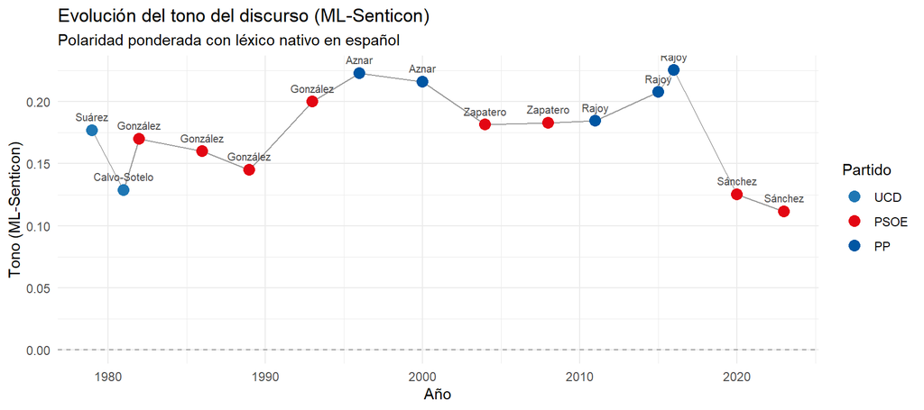

```r
# 1. Convertir la DFM (sin lematizar, para maximizar coincidencias con el
#    léxico) a formato largo y cruzar con ML-Senticon
dfm_discursos_raw <- dfm(tokens(discursos, remove_punct = TRUE, remove_numbers = TRUE))

meta_df <- data.frame(
  doc_id     = docnames(discursos),
  Presidente = docvars(discursos, "Presidente"),
  Partido    = docvars(discursos, "Partido"),
  Año        = docvars(discursos, "Año")
)

sentimiento_ml <- tidytext::tidy(dfm_discursos_raw) %>%
  rename(doc_id = document, palabra = term, frecuencia = count) %>%
  mutate(palabra = tolower(palabra)) %>%
  inner_join(senticon_df, by = "palabra") %>%
  group_by(doc_id) %>%
  summarise(tono_senticon = sum(polaridad * frecuencia) / sum(frecuencia), .groups = "drop") %>%
  left_join(meta_df, by = "doc_id")

# 2. Gráfico alineado estéticamente con la versión NRC (6.1), para comparar a simple vista
ggplot(sentimiento_ml, aes(x = Año, y = tono_senticon)) +
  geom_hline(yintercept = 0, linetype = "dashed", color = "grey60") +
  geom_line(color = "grey60") +
  geom_point(aes(color = Partido), size = 3.5) +
  geom_text(aes(label = nombres_cortos[as.character(Presidente)]),
            vjust = -1.1, size = 2.7, color = "grey30", show.legend = FALSE) +
  scale_color_manual(values = colores_partidos) +
  labs(
    title = "Evolución del tono del discurso (ML-Senticon)",
    subtitle = "Polaridad ponderada con léxico nativo en español",
    y = "Tono (ML-Senticon)",
    x = "Año",
    color = "Partido"
  ) +
  theme_minimal()
```

## 6.4 Comparación de ambos métodos de sentimiento

Para ver si NRC (traducido) y ML-Senticon (nativo) coinciden en la tendencia general, los mostramos uno encima del otro compartiendo el mismo eje X (año), con escalas Y **independientes** — no hay garantía de que ambos léxicos midan la polaridad en la misma unidad, así que forzar la misma escala podría dar una impresión de acuerdo o desacuerdo que no es real.

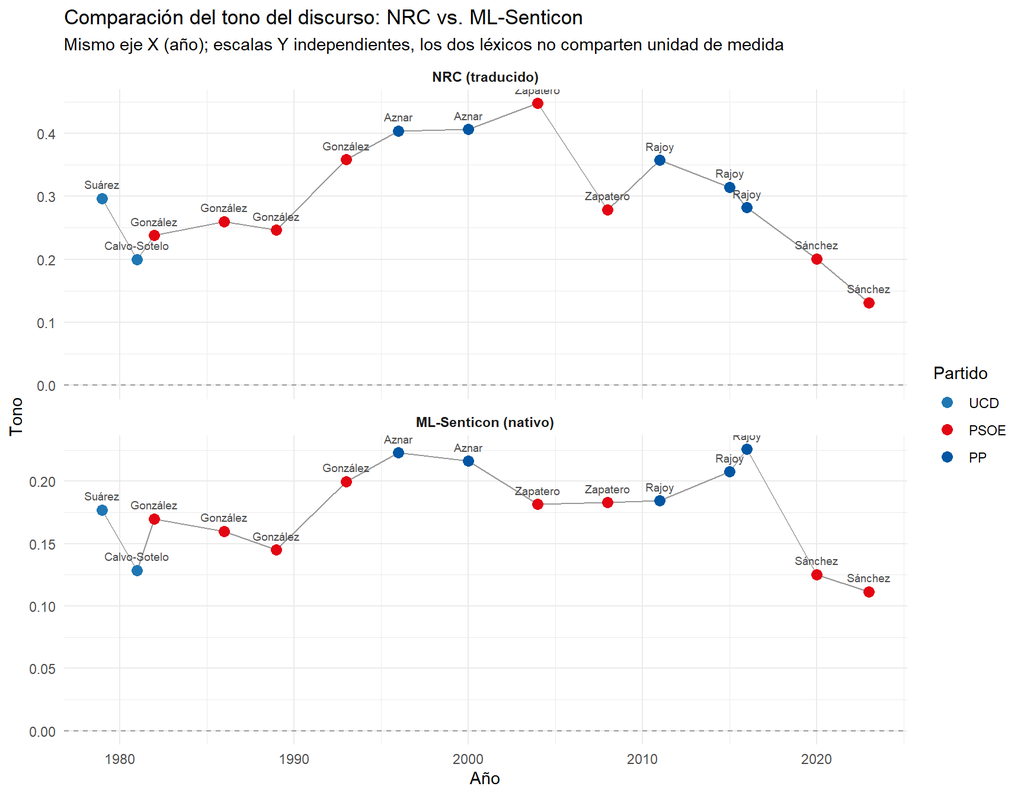

```r
comparacion_sentimiento <- df_sent %>%
  select(doc_id, Presidente, Partido, Año, valor = tono_neto) %>%
  mutate(Método = "NRC (traducido)") %>%
  bind_rows(
    sentimiento_ml %>%
      select(doc_id, Presidente, Partido, Año, valor = tono_senticon) %>%
      mutate(Método = "ML-Senticon (nativo)")
  ) %>%
  mutate(Método = factor(Método, levels = c("NRC (traducido)", "ML-Senticon (nativo)")))

ggplot(comparacion_sentimiento, aes(x = Año, y = valor)) +
  geom_hline(yintercept = 0, linetype = "dashed", color = "grey60") +
  geom_line(color = "grey60") +
  geom_point(aes(color = Partido), size = 3) +
  geom_text(aes(label = nombres_cortos[as.character(Presidente)]),
            vjust = -1.1, size = 2.5, color = "grey30", show.legend = FALSE) +
  scale_color_manual(values = colores_partidos) +
  facet_wrap(~ Método, ncol = 1, scales = "free_y") +
  labs(title = "Comparación del tono del discurso: NRC vs. ML-Senticon",
       subtitle = "Mismo eje X (año); escalas Y independientes, los dos léxicos no comparten unidad de medida",
       x = "Año", y = "Tono", color = "Partido") +
  theme_minimal() +
  theme(strip.text = element_text(face = "bold"))
```

```r
# Coincidencia numérica de tendencia entre ambos léxicos (no de escala, de orden)
comparacion_wide <- df_sent %>%
  select(doc_id, tono_neto) %>%
  inner_join(sentimiento_ml %>% select(doc_id, tono_senticon), by = "doc_id")

test_correlacion <- cor.test(comparacion_wide$tono_neto, comparacion_wide$tono_senticon,
                              method = "spearman")

cat("Correlación de Spearman entre NRC y ML-Senticon: rho = ",
    round(test_correlacion$estimate, 2), ", p-valor = ",
    round(test_correlacion$p.value, 3), "\n",
    "(rho: 1 = coinciden perfectamente en qué discursos son más/menos positivos; ",
    "0 = no hay relación; negativo = tienden a discrepar)\n\n",
    "Aviso: con n=15, la prueba de significancia tiene poca potencia estadística. ",
    "Un p-valor no significativo (> 0.05) no demuestra que los dos léxicos ",
    "discrepen -- puede simplemente reflejar que 15 discursos son pocos para ",
    "detectar la relación con confianza estadística, aunque exista de verdad.\n",
    sep = "")
```

```
## Correlación de Spearman entre NRC y ML-Senticon: rho = 0.78, p-valor = 0.001
## (rho: 1 = coinciden perfectamente en qué discursos son más/menos positivos; 0 = no hay relación; negativo = tienden a discrepar)
##
## Aviso: con n=15, la prueba de significancia tiene poca potencia estadística. Un p-valor no significativo (> 0.05) no demuestra que los dos léxicos discrepen -- puede simplemente reflejar que 15 discursos son pocos para detectar la relación con confianza estadística, aunque exista de verdad.
```

*Usamos correlación de **Spearman** (por rangos) en vez de Pearson a propósito: lo que nos interesa no es si los números coinciden en valor absoluto (que no tienen por qué, al venir de escalas distintas), sino si ambos léxicos **ordenan** los discursos de forma parecida — el más positivo, el segundo más positivo, etc. Con muestras pequeñas y sin ties (empates) en los valores, `cor.test()` calcula además un p-valor exacto en vez de la aproximación asintótica habitual — mejor comportamiento con n=15 que una prueba pensada para muestras grandes.*

# 7. Tabla-resumen consolidada

Reunimos en una sola tabla las métricas clave calculadas en las secciones anteriores — una fila por discurso — para consultar o comparar valores concretos sin releer cada gráfico. Usamos `DT::datatable()` en vez de `kable()` porque el output es HTML: permite ordenar por columna y buscar, algo que una tabla estática no ofrece.

```r
tabla_resumen <- legibilidad %>%
  select(doc_id, Presidente, Partido, Año, n_palabras, Fernandez_Huerta) %>%
  left_join(riqueza_lemmas %>% select(document, MATTR), by = c("doc_id" = "document")) %>%
  left_join(df_sent %>% select(doc_id, tono_neto), by = "doc_id") %>%
  left_join(sentimiento_ml %>% select(doc_id, tono_senticon), by = "doc_id") %>%
  arrange(Año) %>%
  mutate(across(c(Fernandez_Huerta, MATTR, tono_neto, tono_senticon), ~ round(.x, 2))) %>%
  rename(Palabras = n_palabras,
         `Fernández-Huerta` = Fernandez_Huerta,
         `MATTR (Lemas)` = MATTR,
         `Tono neto (NRC)` = tono_neto,
         `Tono (ML-SentiCon)` = tono_senticon)

datatable(
  tabla_resumen,
  rownames = FALSE,
  caption = "Tabla-resumen consolidada con métricas morfosintácticas y de sentimiento",
  options = list(pageLength = 15, order = list(list(3, "asc")))
)
```

| doc_id | Presidente | Partido | Año | Palabras | Fernández-Huerta | MATTR (Lemas) | Tono neto (NRC) | Tono (ML-SentiCon) |
| --- | --- | --- | --- | --- | --- | --- | --- | --- |
| 1979Suarez | Suarez | UCD | 1979 | 12111 | 38.65 | 0.84 | 0.3 | 0.18 |
| 1981CalvoSotelo | CalvoSotelo | UCD | 1981 | 8442 | 48.15 | 0.81 | 0.2 | 0.13 |
| 1982Gonzalez | Gonzalez | PSOE | 1982 | 9398 | 41.67 | 0.85 | 0.24 | 0.17 |
| 1986Gonzalez | Gonzalez | PSOE | 1986 | 11335 | 39.22 | 0.72 | 0.26 | 0.16 |
| 1989Gonzalez | Gonzalez | PSOE | 1989 | 7588 | 42.4 | 0.79 | 0.25 | 0.15 |
| 1993Gonzalez | Gonzalez | PSOE | 1993 | 8117 | 39.08 | 0.81 | 0.36 | 0.2 |
| 1996Aznar | Aznar | PP | 1996 | 10162 | 43.67 | 0.83 | 0.4 | 0.22 |
| 2000Aznar | Aznar | PP | 2000 | 8321 | 51.19 | 0.81 | 0.41 | 0.22 |
| 2004RodriguezZapatero | RodriguezZapatero | PSOE | 2004 | 7868 | 46.62 | 0.82 | 0.45 | 0.18 |
| 2008RodriguezZapatero | RodriguezZapatero | PSOE | 2008 | 9477 | 48.39 | 0.81 | 0.28 | 0.18 |

[output cut: 5 more lines]

# 8. Conclusiones

Para el análisis completo — con el cruce de hallazgos entre secciones, las tablas de datos exactas, y los matices necesarios sobre cada uno de estos puntos — consulta el informe de resultados.